# Analyzing Deforestation Dataset

Author

Sathwik Bollepalli

Published

October 15, 2023

## Q1)

```r
deforest_data=read.csv('data/deforest.csv')
head(deforest_data)
```

```
  id   code        ename     fcover tpop apop     gdp1     gdp2     gdp3
1  1 360121 nanchangxian   3.101124   93   74 2820.376 9743.925 3898.430
2  2 360122      xinjian  39.285467   67   59 2819.388 6300.552 5167.343
3  3 360123         anyi  23.665299   26   19 2101.154 3967.923 4868.308
4  4 360124      jinxian  38.658192   77   65 2386.662 6313.792 3502.143
5  5 360222      fuliang 265.250505   27   23 2199.148 3453.926 2632.704
6  6 360281       leping 100.085463   82   66 1416.134 4476.183 3060.061
    distpvc distport   hwaylen    explen    plain elev prec slope temp  temp0
1  21260.86 435763.2  28749.55 21419.860 0.922216   19 1569  0.07 17.5 6384.1
2  33245.34 453378.0  13618.60  2173.066 0.666383   30 1521  0.33 17.2 6290.0
3  37650.58 489738.7  26491.12  8121.573 0.379204   70 1571  1.49 16.8 6136.3
4  46479.27 407609.2  54049.56 16306.070 0.512833   28 1619  0.28 17.5 6423.5
5 168570.30 366528.5 129787.80 11673.830 0.087788  190 1758  2.91 16.0 5856.9
6 134398.80 350229.9 136160.30 13042.650 0.354071   76 1758  1.17 17.2 6293.6
    area policy
1 188635      0
2 234934      1
3  65605      0
4 194959      1
5 329200      0
6 197469      0
```

a) **Solution**

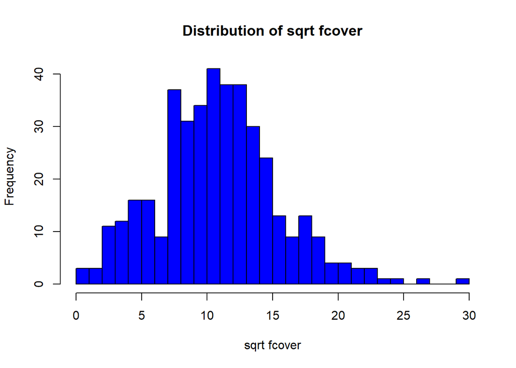

```r
library(ggplot2)

hist(sqrt(deforest_data$fcover), breaks=30, col="blue", main="Distribution of sqrt fcover", xlab="sqrt fcover", ylab="Frequency")
```

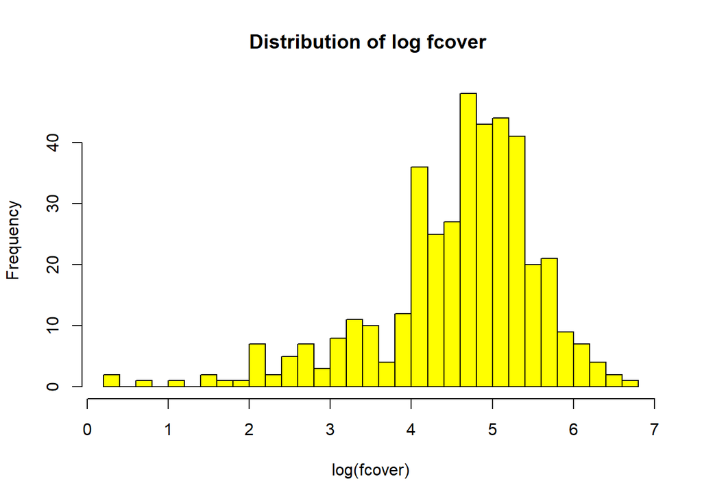

```r
hist(log(deforest_data$fcover+1), breaks=30, col="yellow", main="Distribution of log fcover ", xlab="log(fcover)", ylab="Frequency")
```

**For Log(fcover)**

When comparing it to a normal distribution, the log fcover distribution has more pronounced peaks and isn’t symmetrical.

**For sqrt(fcover)**

The tail on both sides seem fairly balanced, though there might be a slight positive skewness, but it’s much less pronounced than in the log fcover.

Of the two transformations , SQRT fcover appears more norm ally distributed than log fcover. While it’s not a perfect bell curve, its symmetry and single peak resemble the typical characteristics of a normal distribution more closely.

In regression, it’s beneficial to have data that closely follows a normal distribution. This is because such a distribution aligns well with the prerequisites of many statistical methods and models. In out case, the SQRT transformation seems to be a more fitting choice.

```r
model_sqrt_fcover <- lm(sqrt(fcover) ~ area + tpop + apop + gdp1 + gdp2 + gdp3 + distpvc +distport + hwaylen + explen + plain + elev + prec + slope + temp + temp0 + policy, data=deforest_data)
summary(model_sqrt_fcover)
```

```
Call:
lm(formula = sqrt(fcover) ~ area + tpop + apop + gdp1 + gdp2 +
    gdp3 + distpvc + distport + hwaylen + explen + plain + elev +
    prec + slope + temp + temp0 + policy, data = deforest_data)

Residuals:
     Min       1Q   Median       3Q      Max
-14.9651  -1.0581   0.0872   1.1845   4.8991

Coefficients:
              Estimate Std. Error t value Pr(>|t|)
(Intercept)  6.928e+00  1.614e+00   4.292 2.24e-05 ***
area         1.953e-05  7.520e-07  25.972  < 2e-16 ***
tpop         3.039e-02  1.914e-02   1.588   0.1131
apop        -4.620e-02  2.136e-02  -2.163   0.0311 *
gdp1         1.588e-04  1.809e-04   0.878   0.3807
gdp2        -5.819e-06  3.785e-05  -0.154   0.8779
gdp3        -1.457e-05  1.562e-05  -0.933   0.3516
distpvc      3.099e-06  2.888e-06   1.073   0.2839
distport    -5.201e-06  5.785e-07  -8.991  < 2e-16 ***
hwaylen     -3.167e-06  2.922e-06  -1.084   0.2792
explen      -1.069e-06  4.665e-06  -0.229   0.8189
plain       -4.288e+00  1.013e+00  -4.234 2.87e-05 ***
elev        -7.084e-05  2.927e-04  -0.242   0.8089
prec         1.308e-03  5.990e-04   2.184   0.0296 *
slope        5.560e-01  4.828e-02  11.517  < 2e-16 ***
temp         2.484e+00  3.173e-01   7.829 4.77e-14 ***
temp0       -6.912e-03  9.924e-04  -6.964 1.42e-11 ***
policy      -2.139e-01  2.291e-01  -0.934   0.3511
---
Signif. codes:  0 '***' 0.001 '**' 0.01 '*' 0.05 '.' 0.1 ' ' 1

Residual standard error: 1.922 on 387 degrees of freedom
Multiple R-squared:  0.8324,    Adjusted R-squared:  0.825
F-statistic: 113.1 on 17 and 387 DF,  p-value: < 2.2e-16
```

Variables like are, distport, slope, and plain are very important for predicting fcover. For instance, when area cover goes up, the fcover also tends to go up.

For every unit increase in area, the sqrt_fcover increases by 1.9e-05 units, holding all other predictors constant.

The residuals range from -14.9651 to 4.8991, and the Residual Standard Error is 1.922. This gives an idea about the dispersion of the residuals.

The F-statistic is 113.1 with a p-value of < 2.2e-16, strongly suggesting that the model is statistically significant.

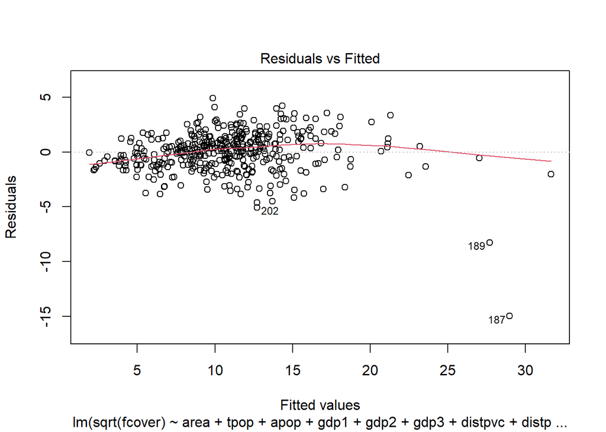

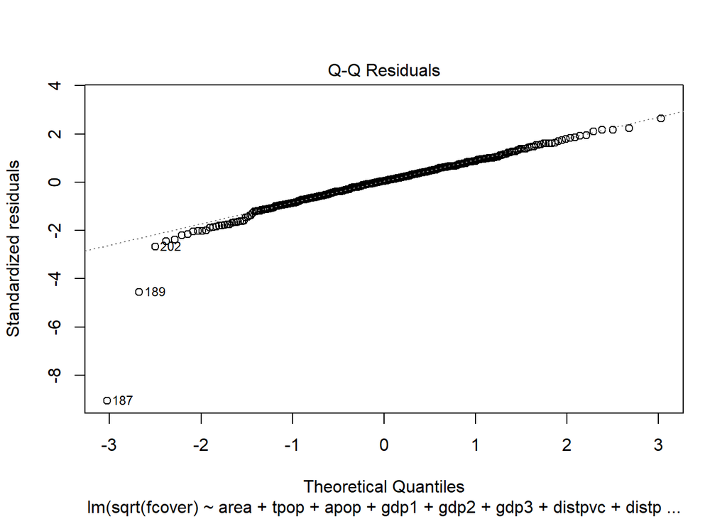

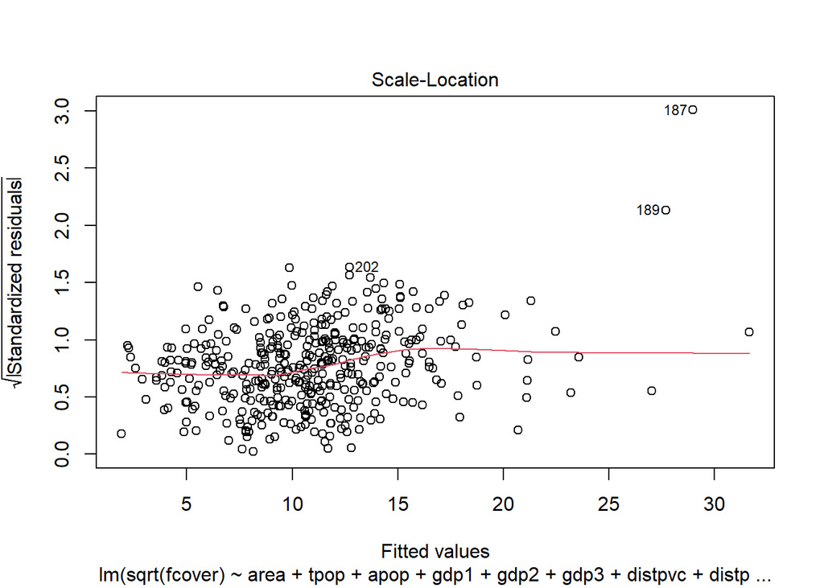

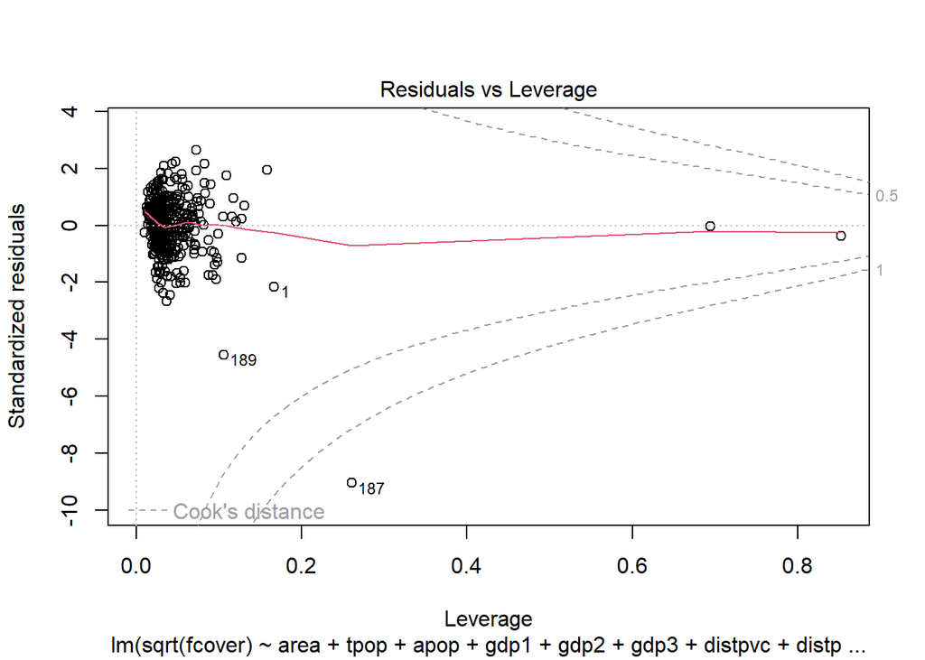

```r
residuals<-residuals(model_sqrt_fcover)
plot(model_sqrt_fcover)
```

The points generally follow the 45-degree line, suggesting that the residuals are mostly normally distributed.

The square root transformation seems to have made the distribution of residuals closer to normal, but there are still some deviations.

The red line representing the smoothed residuals has a gentler slope and less curvature than in the log-transformed plot. This suggests an improved linearity in the relationship between the predictor variables and the transformed dependent variable.

```r
# Using log(fcover) as response
model_fcover_log <- lm(log(fcover+1) ~ area + tpop + apop + gdp1 + gdp2 + gdp3 + distpvc + distport + hwaylen + explen + plain + elev + prec + slope + temp + temp0 + policy, data=deforest_data)
summary(model_fcover_log)
```

```
Call:
lm(formula = log(fcover + 1) ~ area + tpop + apop + gdp1 + gdp2 +
    gdp3 + distpvc + distport + hwaylen + explen + plain + elev +
    prec + slope + temp + temp0 + policy, data = deforest_data)

Residuals:
    Min      1Q  Median      3Q     Max
-1.9003 -0.2548  0.1115  0.3401  0.9762

Coefficients:
              Estimate Std. Error t value Pr(>|t|)
(Intercept)  3.829e+00  4.159e-01   9.205  < 2e-16 ***
area         3.032e-06  1.938e-07  15.646  < 2e-16 ***
tpop         9.506e-03  4.932e-03   1.927 0.054683 .
apop        -1.099e-02  5.503e-03  -1.997 0.046496 *
gdp1         9.687e-05  4.662e-05   2.078 0.038382 *
gdp2        -3.089e-05  9.754e-06  -3.167 0.001664 **
gdp3        -5.678e-06  4.025e-06  -1.411 0.159153
distpvc      1.770e-06  7.443e-07   2.379 0.017867 *
distport    -1.794e-06  1.491e-07 -12.037  < 2e-16 ***
hwaylen     -1.469e-06  7.530e-07  -1.950 0.051873 .
explen      -2.989e-07  1.202e-06  -0.249 0.803765
plain       -9.665e-01  2.610e-01  -3.703 0.000244 ***
elev         1.210e-04  7.543e-05   1.604 0.109521
prec         3.961e-04  1.543e-04   2.566 0.010662 *
slope        1.390e-01  1.244e-02  11.175  < 2e-16 ***
temp         2.819e-01  8.177e-02   3.447 0.000629 ***
temp0       -7.945e-04  2.557e-04  -3.107 0.002031 **
policy       9.231e-02  5.904e-02   1.563 0.118761
---
Signif. codes:  0 '***' 0.001 '**' 0.01 '*' 0.05 '.' 0.1 ' ' 1

Residual standard error: 0.4951 on 387 degrees of freedom
Multiple R-squared:  0.7695,    Adjusted R-squared:  0.7594
F-statistic:    76 on 17 and 387 DF,  p-value: < 2.2e-16
```

When all predictors are zero, the expected logarithm of fcover is approximately 3.829, which is represented by the intercept.

For every unit increase in area, the logarithm of fcover increases by 0.00000303, holding all other predictors constant.

The model provides a reasonably good fit to the data, explaining about 77% of the variance in the logarithm of fcover.

Variables such as tpop, gdp3, hwaylen, explen, elev, and policy have p-values greater than 0.05, indicating they are not statistically significant.

The F-statistic is 76 with a p-value of < 2.2e-16, strongly suggesting that the model is statistically significant.

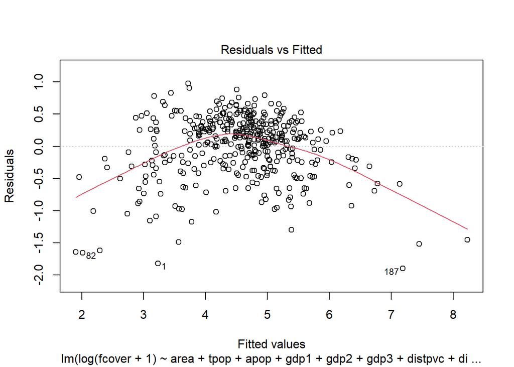

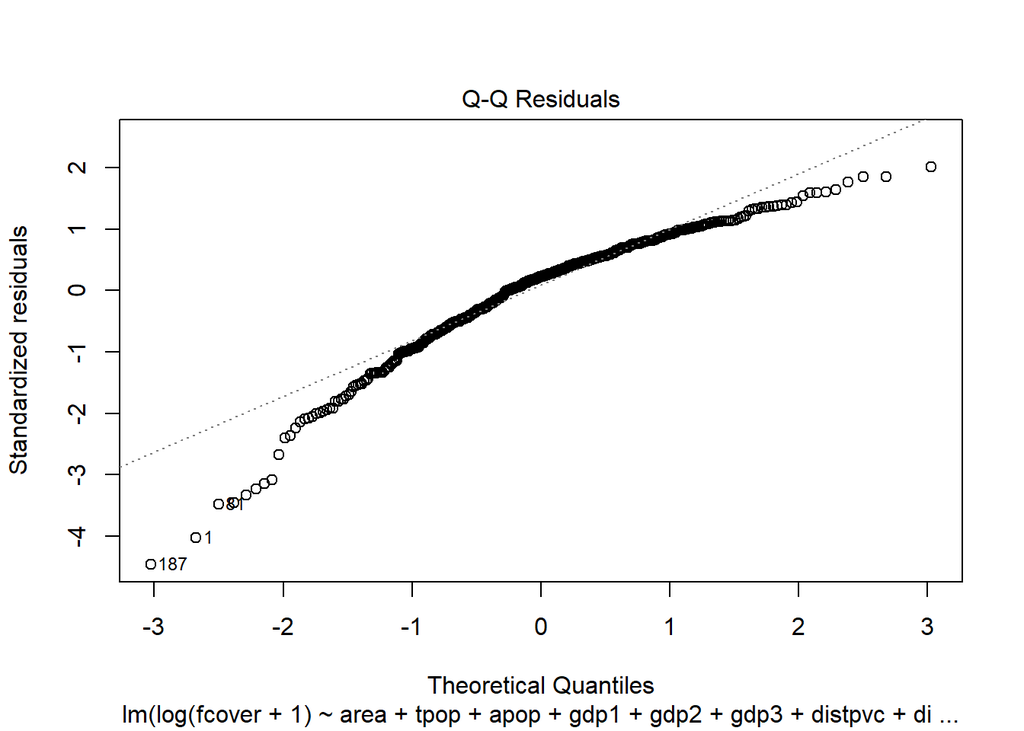

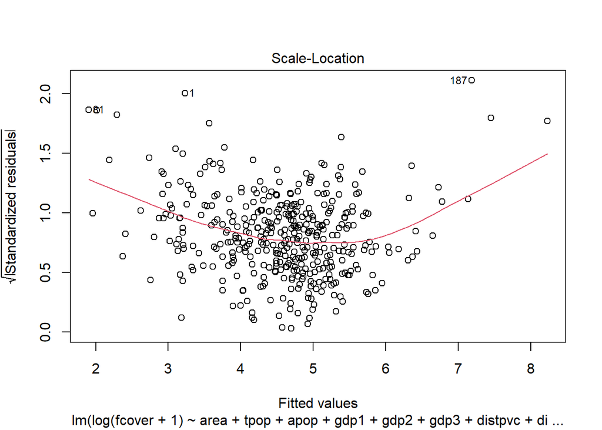

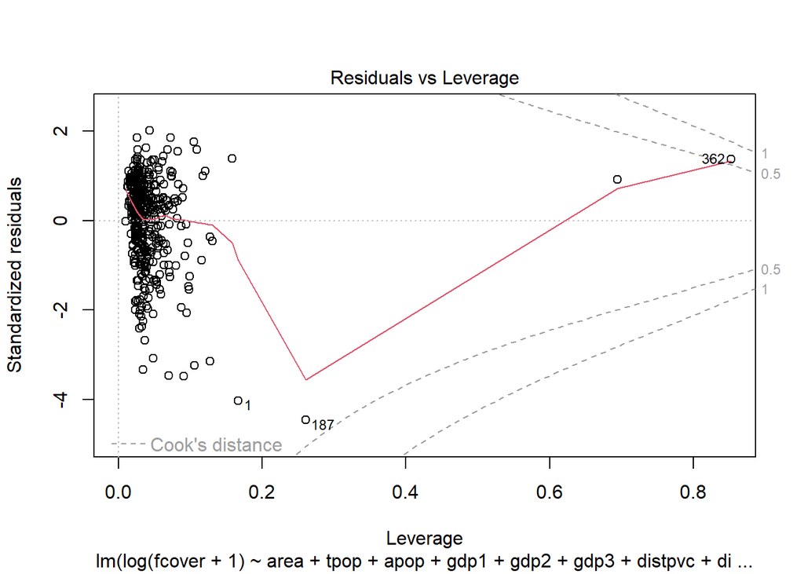

```r
residuals<-residuals(model_fcover_log)
plot(model_fcover_log)
```

This indicates that the log transformation also seems effective in making the residuals more normally distributed.

Point 187 continues to deviate significantly from the expected line, reaffirming that it might be an influential point or an outlier in our dataset.

The residuals should be evenly scattered around the horizontal line at 0 across all levels of fitted values. In this plot, there seems to be a slight funnel shape, especially noticeable at lower and higher fitted values. This might suggest the presence of heteroscedasticity.

**Comparing the Log and SQRT transformation models:**

The model using sqrt(fcover) has a higher R-squared, indicating it explains a larger proportion of the variance in the dependent variable.

The model using sqrt(fcover) also has a higher F-statistic, indicating a better overall fit. However, both models have a very low p-value for the F-statistic, indicating that both are statistically significant.

The model using log(fcover) has a lower RSE, suggesting that the prediction errors are smaller on average for this model.

**I would prefer** using the **sqrt transformed** model because it explains the variability in the response variable higher than compared to the log transformed model and also its residual follow normal distrobution which means the results are reliable.

b) **Solution**

The Box-Cox transformation is a family of power transformations that are used to stabilize variance and make the data more closely follow a normal distribution.

The Box-Cox transformation equation looks like:

$$log(y) \ when\ \lambda=0 \\
(y^\lambda-1)/\lambda \ otherwise$$

If we check the raw distribtuion of the fcover we see that:

The original distribution appears right-skewed with most values clustered in the lower range and a few higher values stretching the distribution’s tail to the right.

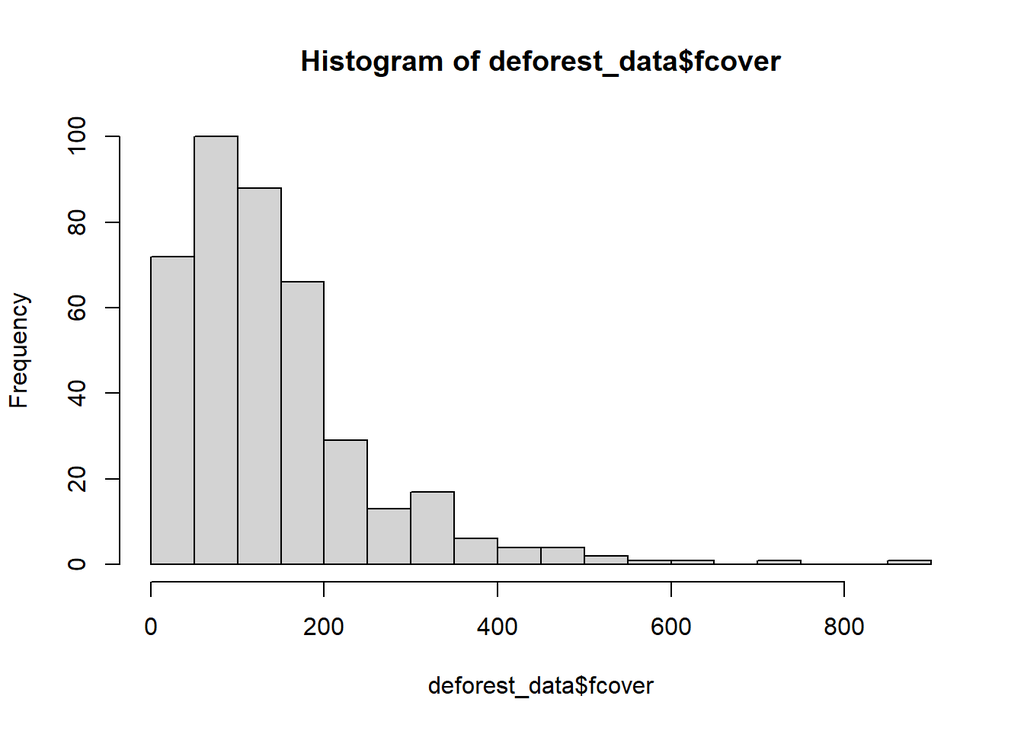

```r
hist(deforest_data$fcover,breaks=30)
```

For fcover, given its skewness, applying the Box-Cox transformation might help in identifying an optimal transformation (value of $\lambda$) that makes the data more normal.

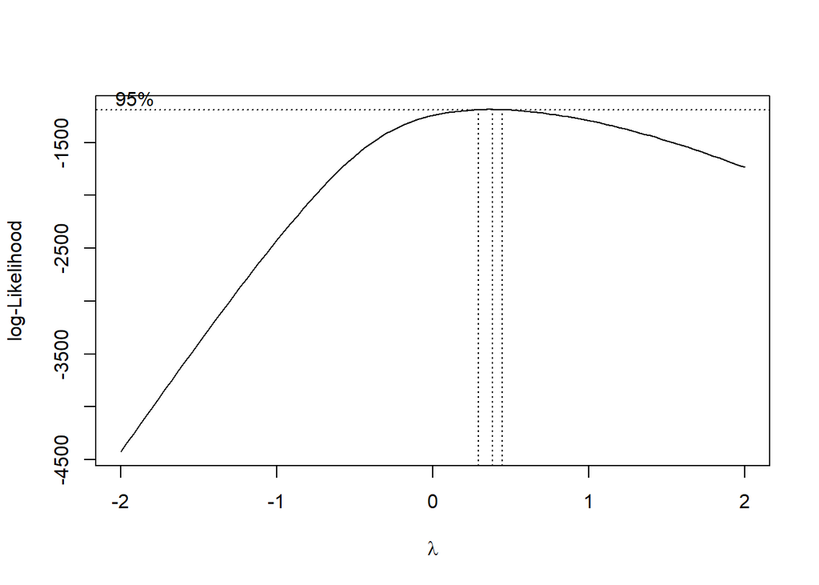

```r
library(MASS)

# Determine optimal lambda

lambda_range <- seq(-2, 2, by = 0.1)

lambda_optimal <- boxcox(deforest_data$fcover ~ 1, lambda = lambda_range, plotit = TRUE)$lambda
```

The shape of the curve gives a visual representation of how the log-likelihood changes with different λ values. The peak of the curve represents the optimal λ value for the Box-Cox transformation, which is the value that maximizes the log-likelihood.

Applying the square root transformation can help stabilize variance and make the distribution more symmetric.

Lets check the distribution of fcover after applying sqrt transformation.

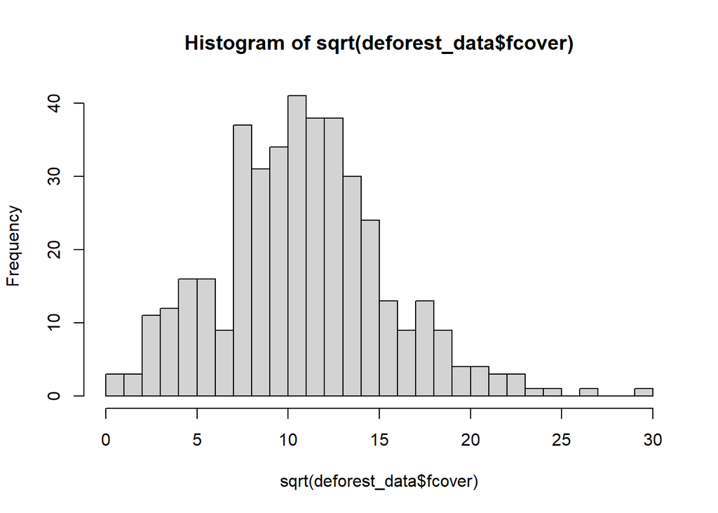

```r
hist(sqrt(deforest_data$fcover),breaks=30)
```

After applying the square root transformation, the data looks more symmetric and less skewed compared to the original distribution. This indicates that the square root transformation has had a positive effect in terms of normalizing the data.

Therefore **using** the **square root of fcover as the response in the MLR model seems reasonable.**

## Q2)

```r
library('RobStatTM')
data('waste')
head(waste)
```

```
  Land Metals Trucking Retail Restaurants SolidWaste
1  102     69      133    125          36     0.3574
2 1220    723     2616    953         132     1.9670
3  139    138       46     35           6     0.1862
4  221    637      153    115          16     0.3816
5   12      0        1      9           1     0.1512
6    1     50        3     25           2     0.1449
```

a) **Solution**

```r
model=lm(SolidWaste~.,data=waste)
residuals<-residuals(model)
summary(model)
```

```
Call:
lm(formula = SolidWaste ~ ., data = waste)

Residuals:
      Min        1Q    Median        3Q       Max
-0.313964 -0.085317  0.004264  0.075333  0.280372

Coefficients:
              Estimate Std. Error t value Pr(>|t|)
(Intercept)  1.243e-01  3.160e-02   3.934 0.000392 ***
Land        -5.249e-05  1.786e-05  -2.938 0.005895 **
Metals       4.146e-05  1.533e-04   0.271 0.788409
Trucking     2.504e-04  8.831e-05   2.835 0.007663 **
Retail      -8.616e-04  3.753e-04  -2.295 0.027999 *
Restaurants  1.335e-02  2.276e-03   5.868 1.28e-06 ***
---
Signif. codes:  0 '***' 0.001 '**' 0.01 '*' 0.05 '.' 0.1 ' ' 1

Residual standard error: 0.1501 on 34 degrees of freedom
Multiple R-squared:  0.8491,    Adjusted R-squared:  0.8269
F-statistic: 38.25 on 5 and 34 DF,  p-value: 5.094e-13
```

Checking normality Assumption

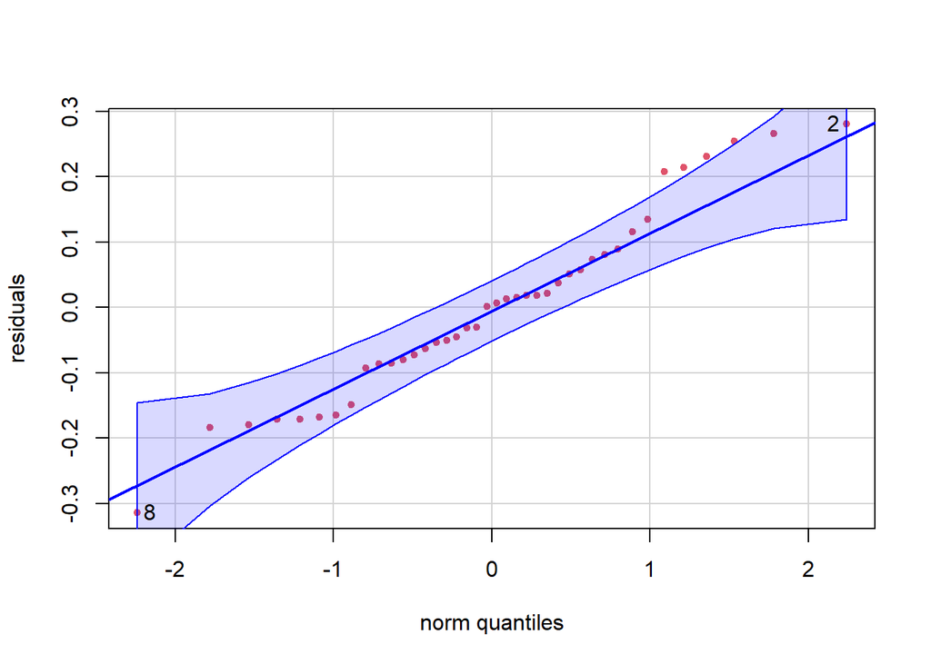

```
[1] 8 2
```

```r
car::qqPlot(residuals, main = NA, pch = 19, col = 2, cex = 0.7)
```

```r
shapiro.test(residuals)
```

```
    Shapiro-Wilk normality test

data:  residuals
W = 0.96842, p-value = 0.3203
```

The W statistic is 0.96842. Values of W close to 1 indicate that the data are well-modeled by a normal distribution.

The p-value is 0.3203. Typically, a p-value greater than 0.05 indicates that we fail to reject the null hypothesis, which means that we do not have sufficient evidence to say that the data are not normally distributed.

The test suggests that the residuals are approximately normally distributed.

Most of the data points are closely aligned with the blue line, which indicates that the residuals are approximately normally distributed.

While the residuals of the model mostly seem to follow the normal distribution, a few potential outliers or influential points.

Checking Linearity Assumption and constant variance

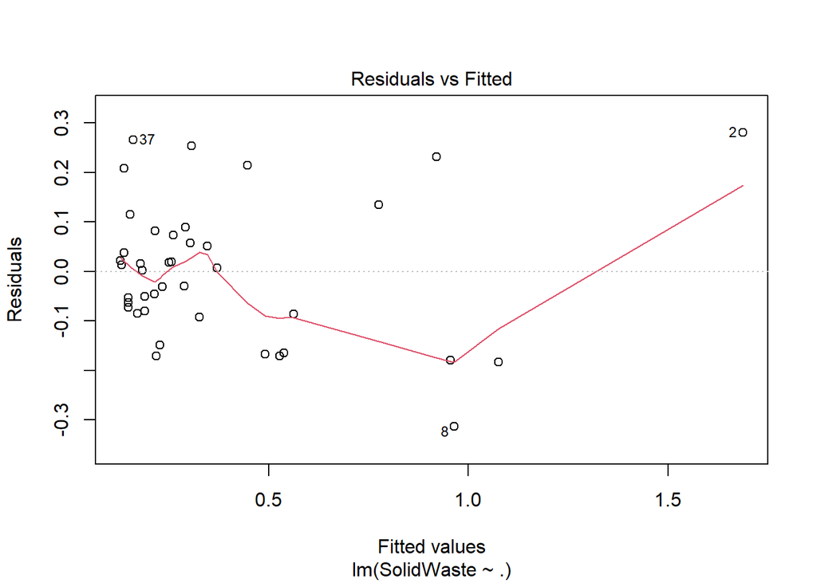

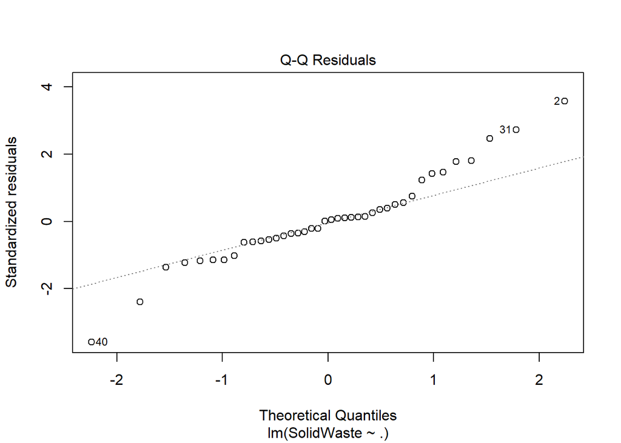

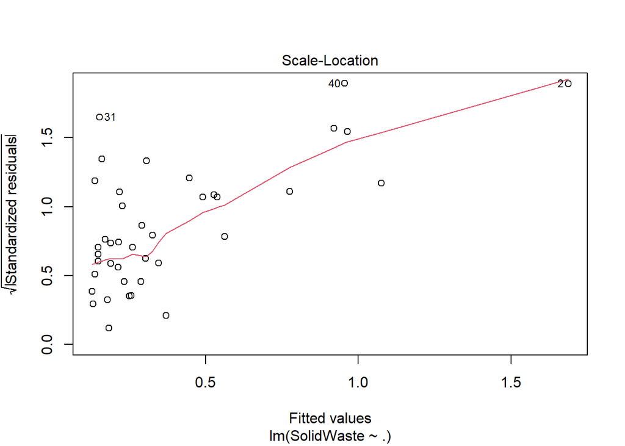

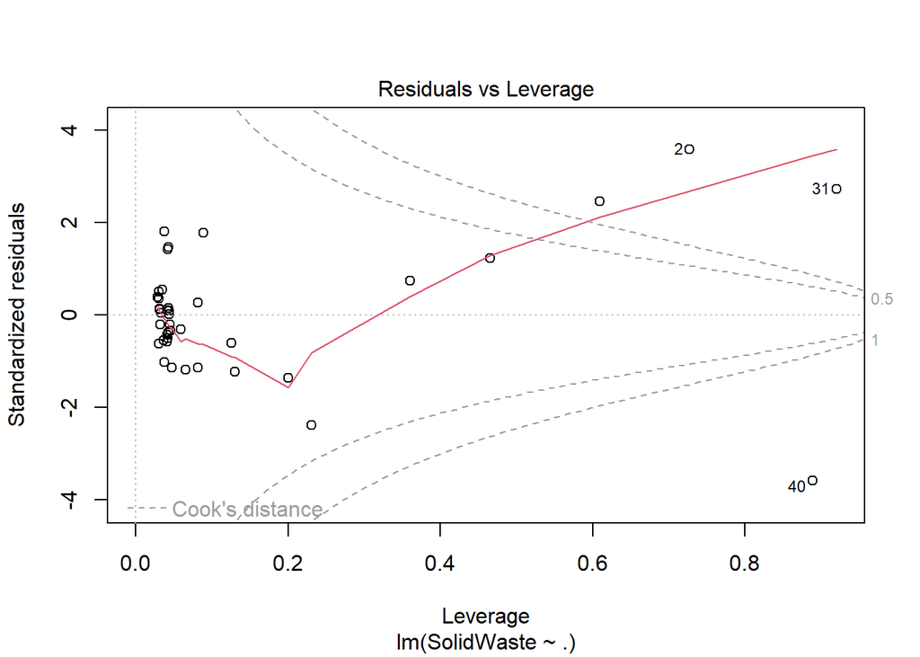

```r
plot(model)
```

**Residuals vs Fitted** plot is used to detect non-linearity and unequal error variances. Ideally, we’d like to see a random scatter of points. The red line should be horizontal and close to 0.The slightly curved red line in our plot suggests that the model might not be capturing some non-linearity in the data.

**Scale-Location** plot is used to check the assumption of equal variance (homoscedasticity). A horizontal red line with points randomly scattered around it is ideal. Again, there seems to be a pattern here, suggesting that the variances of the residuals are not constant.

b) **Solution**

```r
studentized_residuals <- rstudent(model)
potential_outliers <- which(abs(studentized_residuals) > 2)
outlier_data <- waste[potential_outliers, ]
print(outlier_data)
```

```
   Land Metals Trucking Retail Restaurants SolidWaste
2  1220    723     2616    953         132     1.9670
8  2032     44      409    540          98     0.6512
15   42      4       78     41          61     1.1520
31 8983     37      236     77          38     0.2699
40 4790   2046     3719     31           7     0.7759
```

Outliers are the data points that do not fit the trend. They can be either very high or very low values.

Outliers are observations that have unusually large or small residuals.

Outliers can unduly influence the estimates of the model parameters, making the model less reliable for predictions.

**Land**: Observations 31 and 40 have considerably high values compared to others, suggesting they might have an unusually large amount of land.

**Metals**: Observation 40 stands out with a value of 2046, which is much higher compared to the other observations in the outlier list.

**Trucking**: Observations 2 and 40 have values 2616 and 3719 respectively, indicating potentially high trucking figures compared to the other outliers.

Observations 2, 8, 15, 31, and 40 were flagged as potential outliers. Among these, observations 2, 31 and 40 appear to have unusual values in multiple variables, especially in **`Land`**, **`Metals`**, and **`Trucking`**.

c) **Solution**

```r
par(mfrow=c(1,1))

n <- nrow(waste)
p <- ncol(waste)-1
(hilev <- which(influence(model)$hat > max(2*(p+1)/n,0.5)))
```

```
 2 15 31 40
 2 15 31 40
```

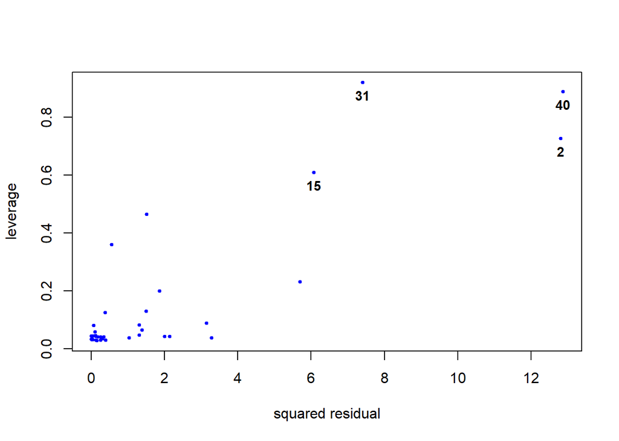

```r
plot(rstandard(model)^2, influence(model)$hat, pch =19, cex=0.5, col="blue",
     xlab = "squared residual", ylab = "leverage")
inf0 <- which(influence(model)$hat > 0.5)
text(rstandard(model)[hilev]^2, influence(model)$hat[hilev],
     labels = inf0, cex = 0.9, font =2, pos =1)
```

```r
hat_vals <- hatvalues(model)

threshold <- 2 * length(coef(model)) / nrow(waste)


high_leverage_points <- which(hat_vals > threshold)


print(waste[high_leverage_points, ])
```

```
   Land Metals Trucking Retail Restaurants SolidWaste
2  1220    723     2616    953         132     1.9670
4   221    637      153    115          16     0.3816
15   42      4       78     41          61     1.1520
31 8983     37      236     77          38     0.2699
35  853   1002     1017    418          57     0.9114
40 4790   2046     3719     31           7     0.7759
```

High leverage points can have a significant influence on the fit of the model, potentially skewing the results and leading to incorrect or misleading interpretations.

Points with high leverage have extreme predictor values (X values).

In this plot, the y-axis represents leverage. Points that are higher up on the y-axis have higher leverage.

**Land**: Observations 31 and 40 have notably high values compared to others, suggesting they might possess an unusually vast amount of land.

**Metals**: Observation 40 has a significant value of 2046, whereas the rest have much lower values, with observation 15 having the smallest value of 4.

**Retail**: Observation 2 leads with a value of 953, followed by observation 35 with 418. The other values are relatively lower, with observation 40 having the least value of 31.

Observations 31, 15, 40, and 2 have notably higher leverage than the other points, indicating they are high leverage points. These values make these observations stand out and thereby increase their leverage in the model.

d) **Solution**

```r
cooks_d <- cooks.distance(model)
influential_cooks <- which(cooks_d > 4/40)
print(waste[influential_cooks, ])
```

```
   Land Metals Trucking Retail Restaurants SolidWaste
2  1220    723     2616    953         132     1.9670
8  2032     44      409    540          98     0.6512
15   42      4       78     41          61     1.1520
31 8983     37      236     77          38     0.2699
35  853   1002     1017    418          57     0.9114
40 4790   2046     3719     31           7     0.7759
```

Cook’s distance measures the influence of each observation on all the fitted values. It’s a combination of leverage and residuals.

**Cook’s distance** measures how much **all the predicted values** would change if a specific observation were excluded. It accounts for the impact of an observation on the entire model.

When an observation has a large Cook’s distance, it indicates that the inclusion of that data point significantly affects the position and slope of the regression line.

```r
library(car)
dffits_vals <- dffits(model)

# Using the rule of thumb
threshold_dffits <- 2*sqrt(length(coef(model))/nrow(waste))
influential_dffits <- which(abs(dffits_vals) > threshold_dffits)
print(waste[influential_dffits, ])
```

```
   Land Metals Trucking Retail Restaurants SolidWaste
2  1220    723     2616    953         132     1.9670
8  2032     44      409    540          98     0.6512
15   42      4       78     41          61     1.1520
31 8983     37      236     77          38     0.2699
35  853   1002     1017    418          57     0.9114
40 4790   2046     3719     31           7     0.7759
```

DFFITS is an acronym for “Difference in Fits.” It measures the change in predicted value for an observation when that specific observation is left out of the regression.

**DFFITS** focuses on the impact of omitting a specific observation on its own predicted value. It pinpoints how much the predicted score for an **individual data point** would change if that point were not included in the regression.

## Q3)

Variance inflation factor measures how much the behavior (variance) of an independent variable is influenced, or inflated, by its interaction/correlation with the other independent variables.

VIF equal to 1 = variables are not correlated

VIF between 1 and 5 = variables are moderately correlated

VIF greater than 5 = variables are highly correlated

```r
vif_values <- vif(model)
print(vif_values)
```

```
       Land      Metals    Trucking      Retail Restaurants
   1.415870    5.625816    6.786948    8.310634    7.712421
```

The variable Land has a VIF value of 1.415870, suggesting no significant multicollinearity.

Metals, Trucking, Retail, and Restaurants have VIF values greater than 5, indicating high multicollinearity among these predictors.

As several predictors have VIF values greater than 5, there is evidence of multicollinearity in the model. In this case multicollinearity can inflate the variance of the regression coefficients, making them unstable.

It might be beneficial to employ ridge regression, which can help in managing multicollinearity by adding a penalty to the coefficients. Ridge regression can shrink the coefficients towards zero, reducing the impact of multicollinearity.

```r
library(glmnet)
x <- as.matrix(waste[, -ncol(waste)])
y <- waste$SolidWaste

ridge_model <- glmnet(x, y, alpha=0)


cv.ridge <- cv.glmnet(x, y, alpha=0)
best_lambda=cv.ridge$lambda.min

final_ridge_model <- glmnet(x, y, alpha = 0, lambda = best_lambda)
coefficients <- coef(final_ridge_model)
coefficients
```

```
6 x 1 sparse Matrix of class "dgCMatrix"
                       s0
(Intercept)  1.740644e-01
Land        -1.434427e-05
Metals       1.168928e-04
Trucking     1.203099e-04
Retail       3.715687e-04
Restaurants  5.062606e-03
```

Ridge regression applies a penalty to large coefficients. This diminishes the impact of correlated predictors, ensuring no single variable dominates the model due to multicollinearity.